# R Notebook

# Carrega bibliotecas

Geralmente fazemos o carregamento da biblioteca no início de cada rotina utilizando a função `library()`. Essa prática ajuda a rodar qualuqer rotina garantindo que as bibliotecas necessárias serão chamadas antes que as funções específicas sejam utilizadas. O comando `library(tidyverse)`, a partir do *tidyverse*, carrega automaticamente um conjunto de bibliotecas muito úteis como `tidyr` e `dplyr` para a manipulação de dados e a biblioteca `ggplot2` que permite gerar gráficos. >> Alerta: Parte dos erros nas rotinas ocorrer por não ter carregado corretamente as bibliotecas necessárias. Por isso, sempre verifique se as bibliotecas necessárias estão devidamente descriminadas.

```r
library(tidyverse)
library(ggthemes)
```

# Carrega dados

Para carregar os dados criei uma rotina especíca no arquivo *carrega_dados_gdrive.R*. Essa rotina específica cria uma conexão com o Googledrive e carrega a primeira planilha do arquivo **Dados Novos**. Caso a planilha mude ou o aquivo mude de nome, isso deve ser alterado no arquivo **.R**. Os dados serão colocados em uma variável `ec`. Para carregar uma rotina externa, por exemplo em um arquivo **.R**, recomendo a utilização da função `source()`. Observe que coloquei o endereço absoluto “~/R…” para indicar o endereço do arquivo **.R**. >> Alerta: Para que você possa utilizar isso no seu computador é importante indicar o endereço no seu próprio computador.

```r
source("~/R/eclass/R/carrega_dados_gdrive.R")
```

# Explorar os dados, primeira aproximação.

Como comentado anteriormente as informações estão colocadas na variável `ec`. Para que tenhamos uma visão geral da estrutura de `ec` podemos utilizar a função `str()` ou a função `glimpse()` oferecida no `tidyverse`. Ele irá imprimir na tela informações sobre a variável como número de linhas (observações) e colunas (variáveis), nome das colunas, tipo da coluna (int: número inteiro, chr: caracter, ftr: fator, etc), primeiras linhas dos dados. Além da estrutura do `data.frame` (ou seja `ec`), podemos imprimir um sumários estatistico dos dados com valores mínimos, máximos, média, mediana, etc. Isso pode ser muito útil para identificar dados anômalos. Para tanto a função que recomendo utilizar é a função `summary()`. >> Alerta: Nenhuma das funções está salvando as informações em novas variáveis. Ou seja, para usar a informação novamente é necessário chamar a função ou então salvar em uma variável específica.

```r
glimpse(ec)

summary(ec)
```

# Selecionando algumas colunas (variáveis do `data.frame`)

Nem sempre queremos manipular toda a informação disponível no `data.frame`. Para isso podemos utilizar a função `select()`. Essa função permitirá selecionar as colunas (variáveis) de interesse. A utilização dessa função é simples e bem direta. Veja que na rotina abaixo coloca no `ecsub` uma seleção de colunas do `ec`. Nessa seleção deixamos as variáveis que contenham no *nome a letra A* e a variável *Sexo*. Nesse caso mantemos todas as observações, ou seja, `ecsub` e `ec` deve ter o mesmo número de linhas. Isso pode ser verificado utilizando a função `glimpse()`. >> Alerta: Veja o **help** da função `select()` com o comando `?select()`. A leitura do texto ajudará a esclarecer melhor sobre como a função deve ser utilizada.

```r
ecsub <- ec %>%
  select(contains("A"), Sexo)
```

# Criar um gráfico com o núemro de Sexo

No R existem diversas forma de criar gráficos. Iremos utilizar a biblioteca `ggplot2`. Nela temos uma forma muito peculiar de criar o gráfico. Primeiramente definimos as variaveis que devem ser incluídas no gráfico com a função `ggplot()`. Essa função recebe o `data.frame`, que neste caso é `ec`, e as variaveis, que devem estar descritas dentro de `aes()`. Somente depois são definidos os parametros do gráfico, como tipo, cores e estilo. Para definir o tipo de gráfio utilizamos o parâmetro `geom_` seguido pelo tipo `bar`. O **help** da biblioteca `ggplot2` deve fornecer detalhes sobre os parâmetros. Além disso, estamos utlizando a biblioteca `ggthemes` que traz alguns temas pré definidos para os gráficos. Utilizando a função `theme_economist()` podemos deixar nosso gráfico com a mesma aparência dos gráficos utlizados na revista The Economist. >> Alerta: Observe que ao final de cada função/linha do `ggplot()` devem ser concluídos com o sinal de `+`. Sem isso a rotina para no meio.

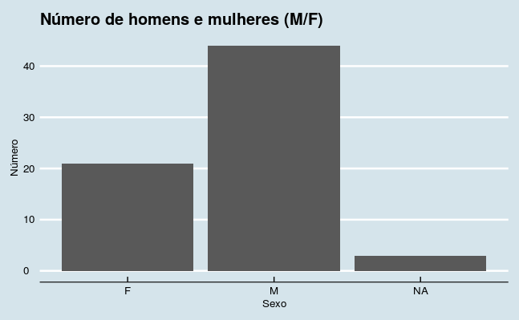

```r
psexo <- ggplot(ec, aes(x=factor(Sexo))) +
  geom_bar(stat="count") +
  theme_economist() +
  labs(title="Número de homens e mulheres (M/F)", x="Sexo", y="Número")
psexo
```